# Color

### Color Frequency

We started off by checking the frequency of occurrences of various colors of diamonds in our data set. It looks like all the colors are represented well enough in our data set.

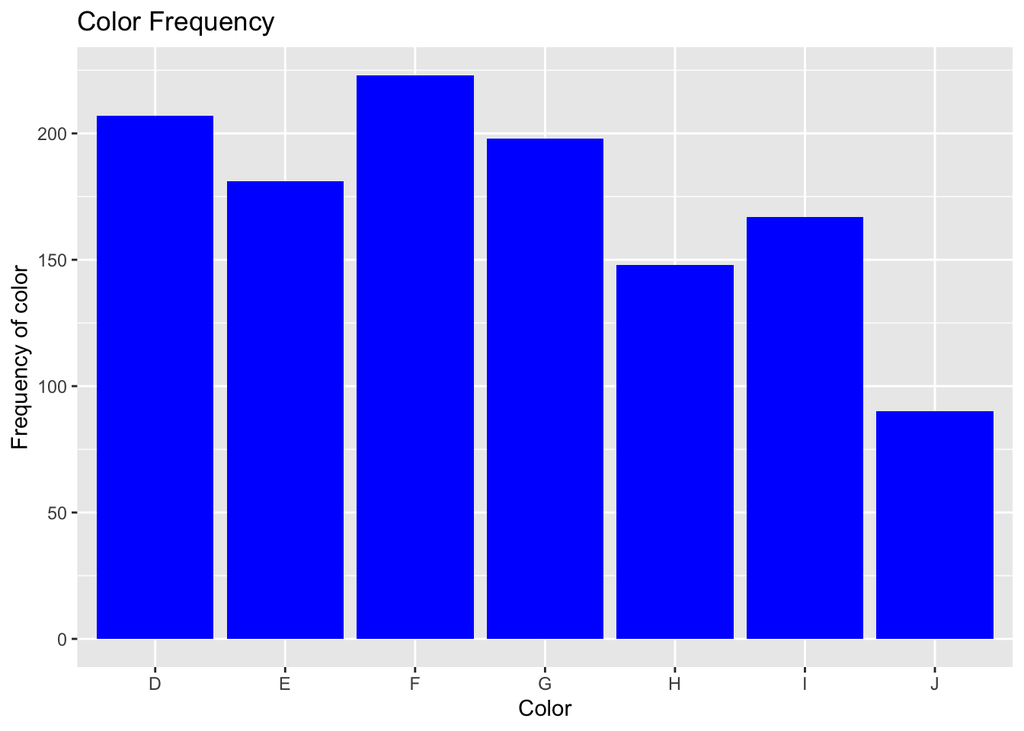

### Price vs Color

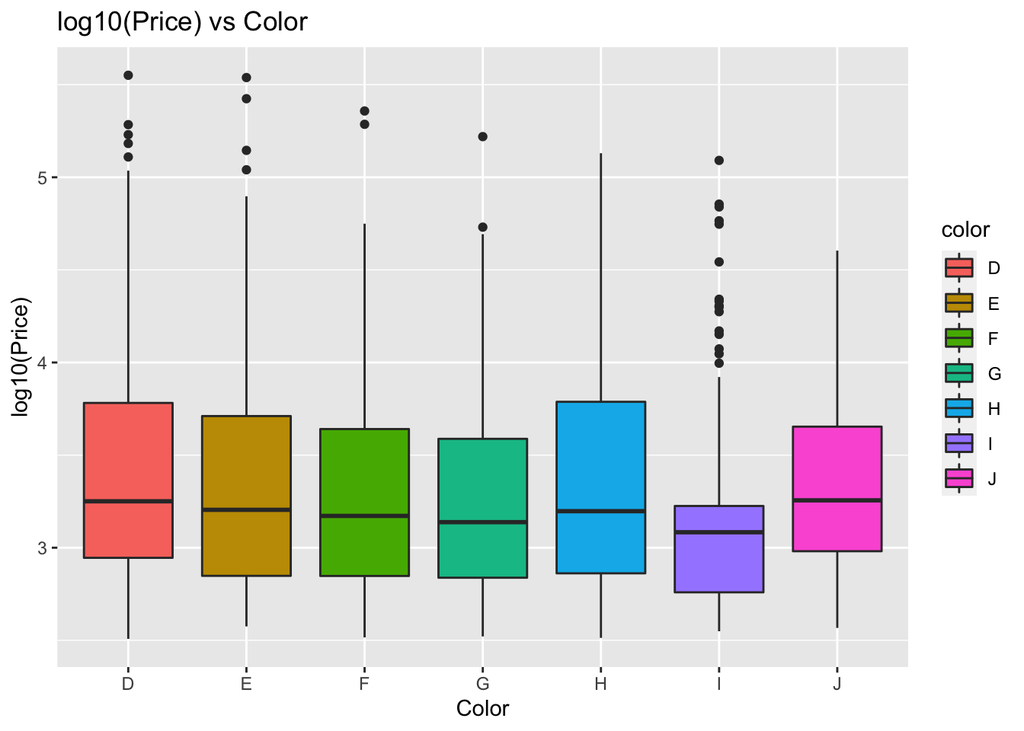

To assess the impact of other variables along with color on the price, we created box plots by grouping the other variables into their respective categories and then assessed the impact of color on price.

### Color and Carat Weight Ranges

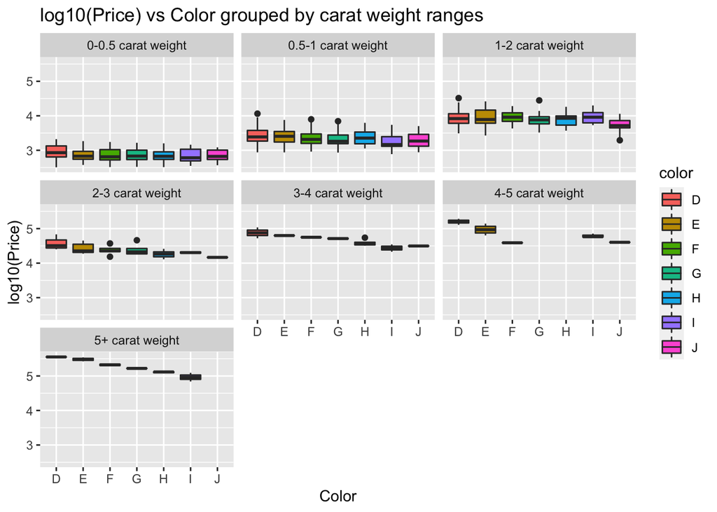

Then to find a correlation between color and carat weight ranges we also created proportion bar charts. This chart will help us answer questions such as does a particular carat weight range occur more often for a particular color in our data set? The most interesting find in the below color and carat weight ranges chart is that the proportion of diamonds with more than 1 carat weight is much higher in both H and J color-grade diamonds. This actually explains why H and J color-grade diamonds overall had a higher than expected mean price, almost comparable to D/E/F diamonds, in the log10(Price) vs Color box plot.

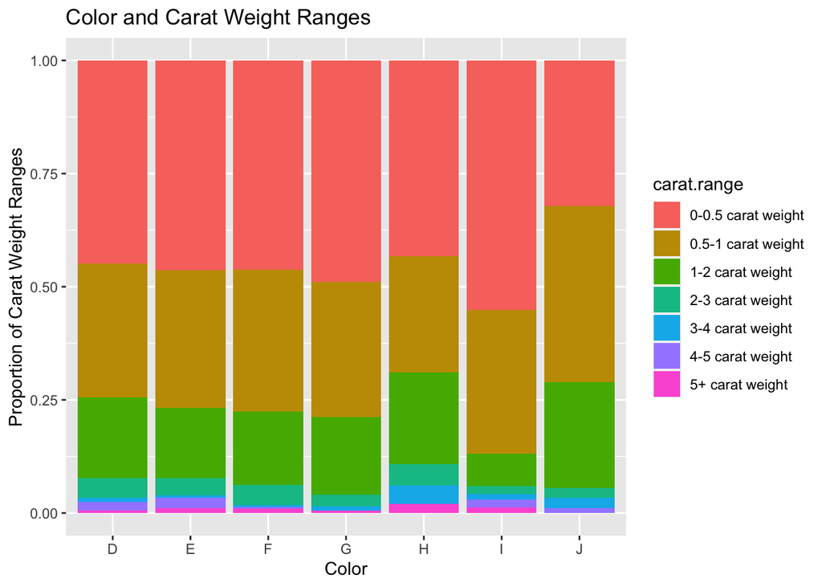

### Color and Cut

To find a correlation between color and cut we also created proportion bar chart. This chart will help us answer questions such as does a particular cut type occur more often for a particular color in our data set? In the below color and cut plot, we can see that the proportion of Astor ideal cut is higher for F color-grade diamond compared to others. But no other major bias was found between color and cut.

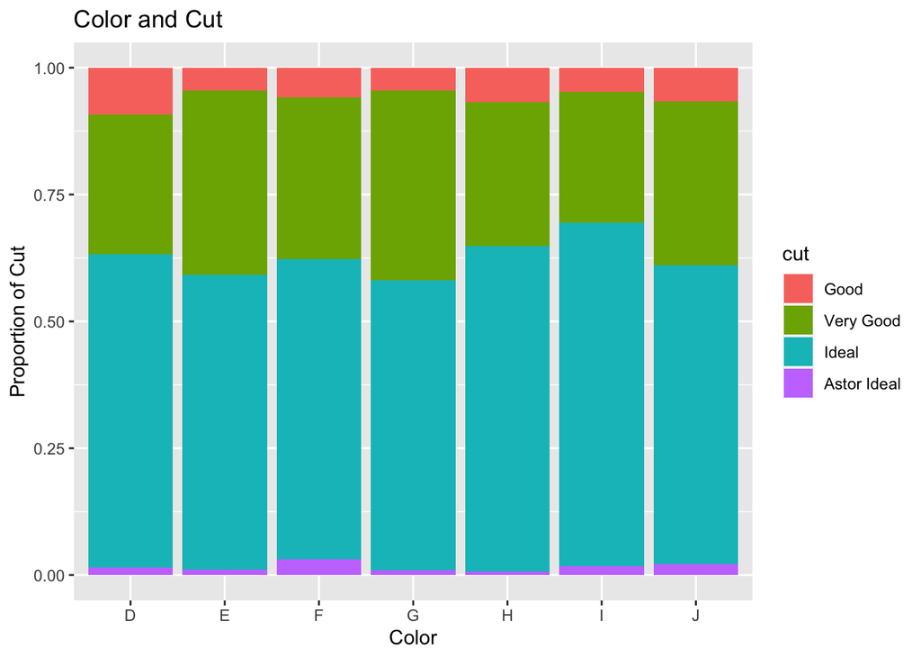

### Color and Clarity

To find a correlation between color and clarity we also created proportion bar chart. This chart will help us answer questions such as does a particular clarity occur more often for a particular color in our data set?. In the below color and clarity plot, we can interestingly see that the best clarity, which is FL, only occurs for D and F grade diamonds in our data set.

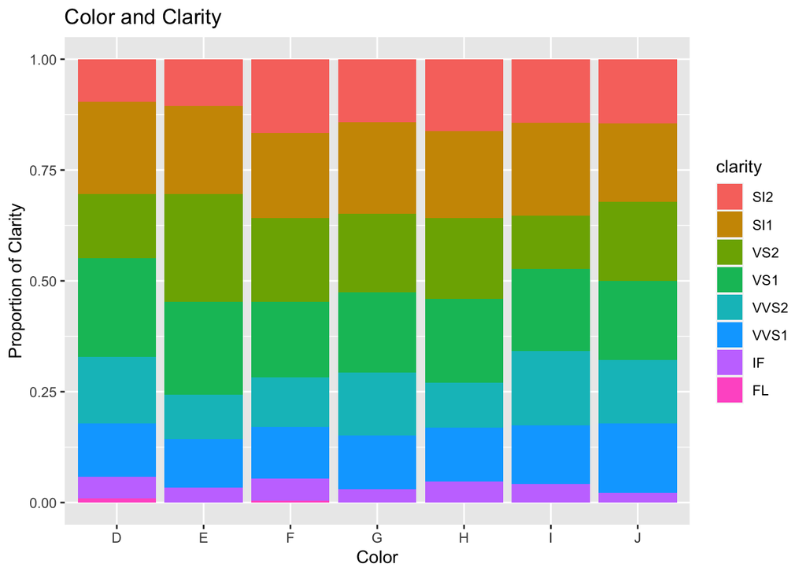